# 5_1_Time_Series_Decomposition_Intro

# References

1. Hyndman, R.J., & Athanasopoulos, G., 2021. *Forecasting: principles and practice*. 3rd edition.
2. Kourentzes, Nikolaus. *Additive and multiplicative seasonality - can you identify them correctly?* [Link](https://kourentzes.com/forecasting/2014/11/09/additive-and-multiplicative-seasonality/#comments)

# Packages

```r
library(fpp3)
library(seasonal)
```

# Additive vs. Multiplicative decomposition

A time series mightbe decomposed, in general terms, in three different components:

- A seasonal component $S_t$
- A trend-cycle component $T_t$
  - Some authors separate the trend and cycle component. Here **we consider trend-cycle** because the usual decomposition algorithms extract them together, not separately.
- The remainder component $R_t$

Typically we distinguish between **two types of decomposition schemes**:

- An **additive scheme**:

$$\boxed{y_t = S_t + T_t + R_t}$$

- A **multiplicative scheme**:

$$\boxed{y_t = S_t\times{T_t}\times{R_t}} \\
or \\
\boxed{\log{y_t}= log{S_t} + \log{T_t} + \log{R_t}}$$

- **Additive scheme**
  - The variation around the trend-cycle, of the seasonal pattern, does NOT vary with the level of the time series (with the trend component value).
- **Multiplicative scheme**
  - The variation around the trend-cycle, of the seasonal pattern, appears to be proportional to the level of the time series (to the trend component value).

## Two examples known to us

We will explore several methods for obtaining the components of the time series throughout the chapter, but let us first have a look at two examples.

### Additive scheme

We will work with the number of persons employed in retail as shown in Figure 3.5. We can see the monthly number of persons in thousands employed in the retail sector across the US since 1990:

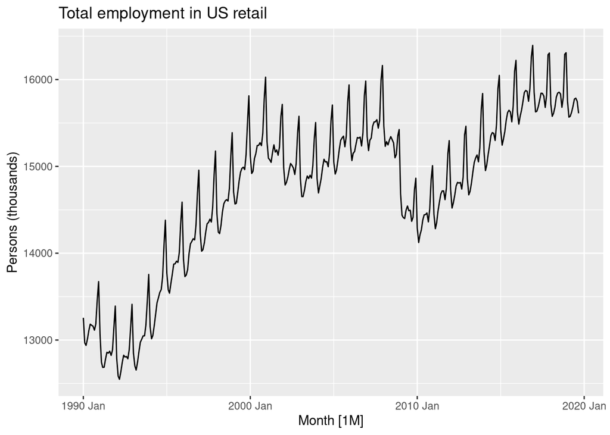

```r
us_retail_employment <- us_employment %>%
  filter(year(Month) >= 1990, Title == "Retail Trade") %>%
  select(-Series_ID)
autoplot(us_retail_employment, Employed) +
  labs(y = "Persons (thousands)",
       title = "Total employment in US retail")
```

With this code we can obtain the components using STL decomposition (more on that later in the chapter):

```r
dcmp <- us_retail_employment %>%
  model(stl = STL(Employed))
components(dcmp)
```

```
## # A dable: 357 x 7 [1M]
## # Key:     .model [1]
## # :        Employed = trend + season_year + remainder
##    .model    Month Employed  trend season_year remainder season_adjust
##    <chr>     <mth>    <dbl>  <dbl>       <dbl>     <dbl>         <dbl>
##  1 stl    1990 Jan   13256. 13288.      -33.0      0.836        13289.
##  2 stl    1990 Feb   12966. 13269.     -258.     -44.6          13224.
##  3 stl    1990 Mar   12938. 13250.     -290.     -22.1          13228.
##  4 stl    1990 Apr   13012. 13231.     -220.       1.05         13232.
##  5 stl    1990 May   13108. 13211.     -114.      11.3          13223.
##  6 stl    1990 Jun   13183. 13192.      -24.3     15.5          13207.
##  7 stl    1990 Jul   13170. 13172.      -23.2     21.6          13193.
##  8 stl    1990 Aug   13160. 13151.       -9.52    17.8          13169.
##  9 stl    1990 Sep   13113. 13131.      -39.5     22.0          13153.
## 10 stl    1990 Oct   13185. 13110.       61.6     13.2          13124.
## # … with 347 more rows
```

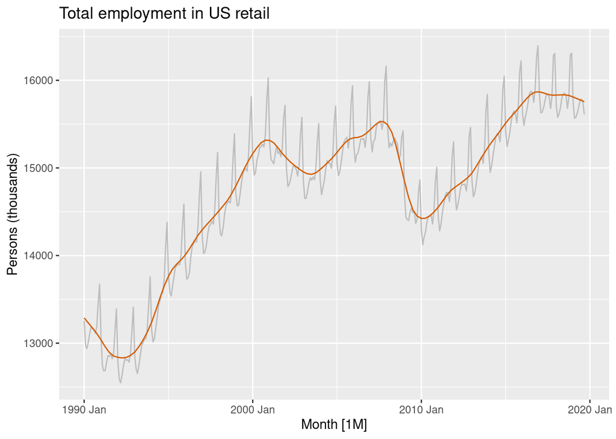

```r
components(dcmp) %>%
  as_tsibble() %>%
  autoplot(Employed, colour="gray") +
  geom_line(aes(y=trend), colour = "#D55E00") +
  labs(
    y = "Persons (thousands)",
    title = "Total employment in US retail"
  )
```

Using autoplot, we can have a look at the components:

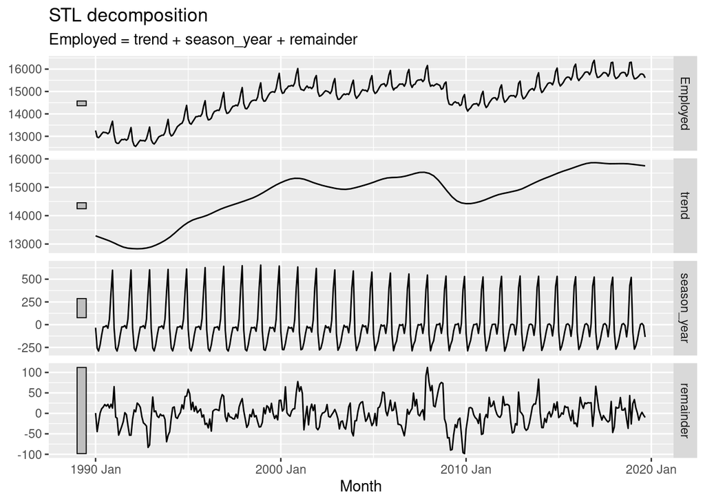

```r
components(dcmp) %>% autoplot()
```

### Multiplicative scheme:

Let us resort again to the monthly medicare Australian prescription data, because it shows a clear multiplicative scheme:

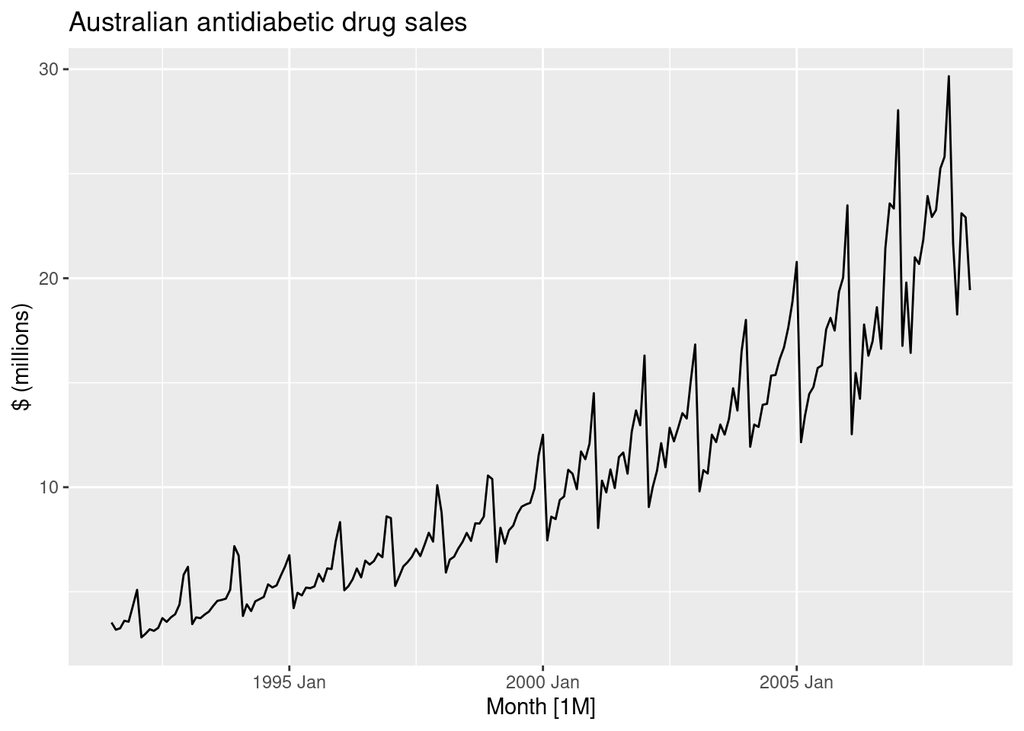

```r
PBS %>%
  filter(ATC2 == "A10") %>%
  select(Month, Concession, Type, Cost) %>%
  summarise(TotalC = sum(Cost)) %>%
  mutate(Cost = TotalC / 1e6) -> a10

autoplot(a10, Cost) +
  labs(y = "$ (millions)",
       title = "Australian antidiabetic drug sales")
```

```r
a10
```

```
## # A tsibble: 204 x 3 [1M]
##       Month  TotalC  Cost
##       <mth>   <dbl> <dbl>
##  1 1991 Jul 3526591  3.53
##  2 1991 Aug 3180891  3.18
##  3 1991 Sep 3252221  3.25
##  4 1991 Oct 3611003  3.61
##  5 1991 Nov 3565869  3.57
##  6 1991 Dec 4306371  4.31
##  7 1992 Jan 5088335  5.09
##  8 1992 Feb 2814520  2.81
##  9 1992 Mar 2985811  2.99
## 10 1992 Apr 3204780  3.20
## # … with 194 more rows
```

```r
a10
```

```
## # A tsibble: 204 x 3 [1M]
##       Month  TotalC  Cost
##       <mth>   <dbl> <dbl>
##  1 1991 Jul 3526591  3.53
##  2 1991 Aug 3180891  3.18
##  3 1991 Sep 3252221  3.25
##  4 1991 Oct 3611003  3.61
##  5 1991 Nov 3565869  3.57
##  6 1991 Dec 4306371  4.31
##  7 1992 Jan 5088335  5.09
##  8 1992 Feb 2814520  2.81
##  9 1992 Mar 2985811  2.99
## 10 1992 Apr 3204780  3.20
## # … with 194 more rows
```

With this code we can obtain the components using X11 decomposition. We use this method because the series is multiplicative (more about that later in the chapter):

```r
x11_dcmp <- a10 %>%
  model(x11 = X_13ARIMA_SEATS(Cost ~ x11())) %>%
  components()
```

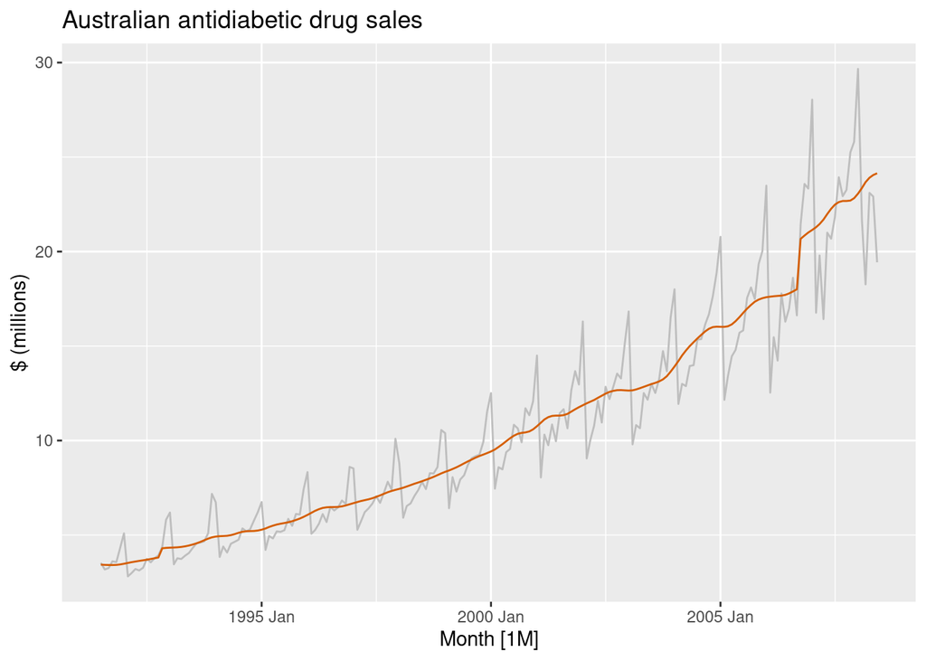

```r
x11_dcmp %>%
  as_tsibble() %>%
  autoplot(Cost, colour="gray") +
  geom_line(aes(y=trend), colour = "#D55E00") +
  labs(
    y = "$ (millions)",
    title = "Australian antidiabetic drug sales"
  )
```

Again we can depict the components using autoplot:

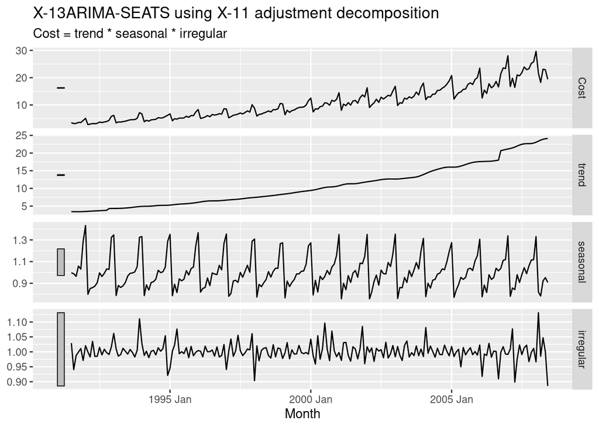

```r
x11_dcmp %>% autoplot()
```

### Multiplicative scheme under different transformations:

Let us look at the effect of applying different transformations of increasing strength to stabilize variations. The purpose is to the multiplicative scheme into an additive one.

Specifically we will apply a **square root**, a **cubic root** and a **log** transformation

```r
a10 <- mutate(a10, sqrt_cost = sqrt(Cost), cbrt_cost = Cost^(1/3), log_cost = log(Cost), inv_cost = -1/Cost)
a10
```

```
## # A tsibble: 204 x 7 [1M]
##       Month  TotalC  Cost sqrt_cost cbrt_cost log_cost inv_cost
##       <mth>   <dbl> <dbl>     <dbl>     <dbl>    <dbl>    <dbl>
##  1 1991 Jul 3526591  3.53      1.88      1.52     1.26   -0.284
##  2 1991 Aug 3180891  3.18      1.78      1.47     1.16   -0.314
##  3 1991 Sep 3252221  3.25      1.80      1.48     1.18   -0.307
##  4 1991 Oct 3611003  3.61      1.90      1.53     1.28   -0.277
##  5 1991 Nov 3565869  3.57      1.89      1.53     1.27   -0.280
##  6 1991 Dec 4306371  4.31      2.08      1.63     1.46   -0.232
##  7 1992 Jan 5088335  5.09      2.26      1.72     1.63   -0.197
##  8 1992 Feb 2814520  2.81      1.68      1.41     1.03   -0.355
##  9 1992 Mar 2985811  2.99      1.73      1.44     1.09   -0.335
## 10 1992 Apr 3204780  3.20      1.79      1.47     1.16   -0.312
## # … with 194 more rows
```

Now let us explore the effect of each transformation in the data (please excuse the spaghetti code style, in a production environment dedicated functions or at least a for loop should have been written to avoid code repetition)

```r
dcmp <- a10 %>%
  model(stl = STL(sqrt_cost))
components(dcmp)
```

```
## # A dable: 204 x 7 [1M]
## # Key:     .model [1]
## # :        sqrt_cost = trend + season_year + remainder
##    .model    Month sqrt_cost trend season_year remainder season_adjust
##    <chr>     <mth>     <dbl> <dbl>       <dbl>     <dbl>         <dbl>
##  1 stl    1991 Jul      1.88  1.82     -0.0218    0.0826          1.90
##  2 stl    1991 Aug      1.78  1.83     -0.0215   -0.0207          1.81
##  3 stl    1991 Sep      1.80  1.83     -0.0154   -0.0155          1.82
##  4 stl    1991 Oct      1.90  1.84      0.0332    0.0242          1.87
##  5 stl    1991 Nov      1.89  1.85      0.0617   -0.0251          1.83
##  6 stl    1991 Dec      2.08  1.86      0.334    -0.120           1.74
##  7 stl    1992 Jan      2.26  1.87      0.372     0.0139          1.88
##  8 stl    1992 Feb      1.68  1.88     -0.249     0.0470          1.93
##  9 stl    1992 Mar      1.73  1.89     -0.148    -0.0124          1.88
## 10 stl    1992 Apr      1.79  1.90     -0.152     0.0439          1.94
## # … with 194 more rows
```

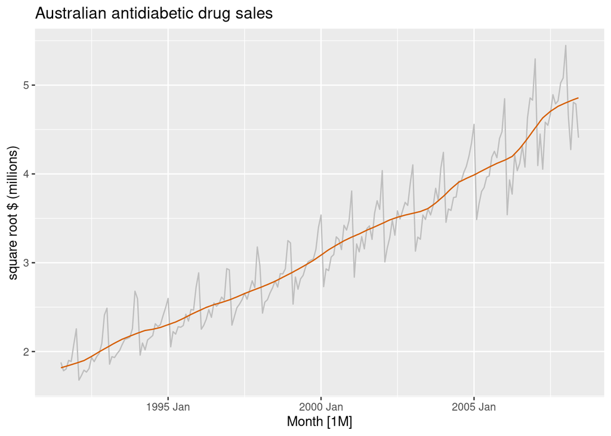

```r
components(dcmp) %>%
  as_tsibble() %>%
  autoplot(sqrt_cost, colour="gray") +
  geom_line(aes(y=trend), colour = "#D55E00") +
  labs(
    y = "square root $ (millions)",
    title = "Australian antidiabetic drug sales"
  )
```

```r
dcmp <- a10 %>%
  model(stl = STL(cbrt_cost))
components(dcmp)
```

```
## # A dable: 204 x 7 [1M]
## # Key:     .model [1]
## # :        cbrt_cost = trend + season_year + remainder
##    .model    Month cbrt_cost trend season_year remainder season_adjust
##    <chr>     <mth>     <dbl> <dbl>       <dbl>     <dbl>         <dbl>
##  1 stl    1991 Jul      1.52  1.49    -0.0100     0.0419          1.53
##  2 stl    1991 Aug      1.47  1.49    -0.0103    -0.0135          1.48
##  3 stl    1991 Sep      1.48  1.50    -0.00720   -0.0101          1.49
##  4 stl    1991 Oct      1.53  1.50     0.0176     0.0134          1.52
##  5 stl    1991 Nov      1.53  1.51     0.0323    -0.0124          1.50
##  6 stl    1991 Dec      1.63  1.51     0.166     -0.0513          1.46
##  7 stl    1992 Jan      1.72  1.52     0.185      0.0179          1.53
##  8 stl    1992 Feb      1.41  1.52    -0.126      0.0161          1.54
##  9 stl    1992 Mar      1.44  1.53    -0.0746    -0.0124          1.51
## 10 stl    1992 Apr      1.47  1.53    -0.0761     0.0186          1.55
## # … with 194 more rows
```

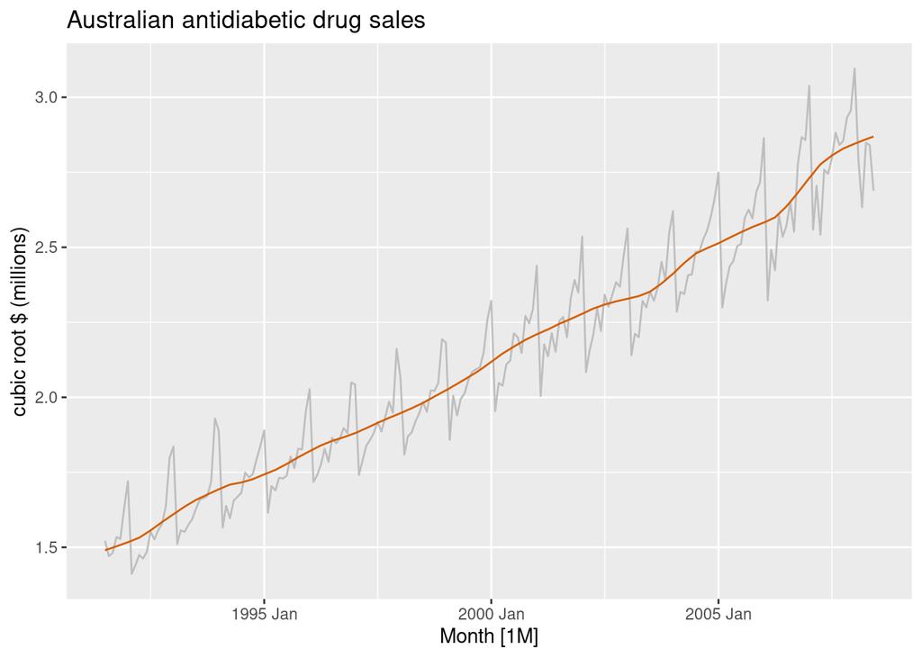

```r
components(dcmp) %>%
  as_tsibble() %>%
  autoplot(cbrt_cost, colour="gray") +
  geom_line(aes(y=trend), colour = "#D55E00") +
  labs(
    y = "cubic root $ (millions)",
    title = "Australian antidiabetic drug sales"
  )
```

```r
dcmp <- a10 %>%
  model(stl = STL(log_cost))
components(dcmp)
```

```
## # A dable: 204 x 7 [1M]
## # Key:     .model [1]
## # :        log_cost = trend + season_year + remainder
##    .model    Month log_cost trend season_year remainder season_adjust
##    <chr>     <mth>    <dbl> <dbl>       <dbl>     <dbl>         <dbl>
##  1 stl    1991 Jul     1.26  1.20     -0.0136  0.0736            1.27
##  2 stl    1991 Aug     1.16  1.21     -0.0162 -0.0344            1.17
##  3 stl    1991 Sep     1.18  1.22     -0.0105 -0.0255            1.19
##  4 stl    1991 Oct     1.28  1.22      0.0332  0.0279            1.25
##  5 stl    1991 Nov     1.27  1.23      0.0600 -0.0196            1.21
##  6 stl    1991 Dec     1.46  1.24      0.278  -0.0567            1.18
##  7 stl    1992 Jan     1.63  1.25      0.311   0.0684            1.32
##  8 stl    1992 Feb     1.03  1.26     -0.221  -0.000911          1.26
##  9 stl    1992 Mar     1.09  1.27     -0.128  -0.0439            1.22
## 10 stl    1992 Apr     1.16  1.27     -0.130   0.0195            1.29
## # … with 194 more rows
```

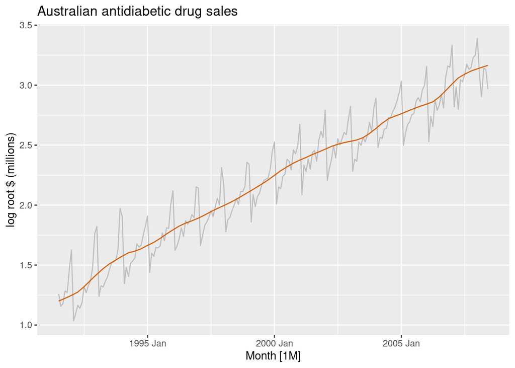

```r
components(dcmp) %>%
  as_tsibble() %>%
  autoplot(log_cost, colour="gray") +
  geom_line(aes(y=trend), colour = "#D55E00") +
  labs(
    y = "log root $ (millions)",
    title = "Australian antidiabetic drug sales"
  )
```

```r
dcmp <- a10 %>%
  model(stl = STL(inv_cost))
components(dcmp)
```

```
## # A dable: 204 x 7 [1M]
## # Key:     .model [1]
## # :        inv_cost = trend + season_year + remainder
##    .model    Month inv_cost  trend season_year remainder season_adjust
##    <chr>     <mth>    <dbl>  <dbl>       <dbl>     <dbl>         <dbl>
##  1 stl    1991 Jul   -0.284 -0.300  -0.0000614   0.0161         -0.283
##  2 stl    1991 Aug   -0.314 -0.298  -0.00252    -0.0138         -0.312
##  3 stl    1991 Sep   -0.307 -0.297  -0.000907   -0.00998        -0.307
##  4 stl    1991 Oct   -0.277 -0.295   0.00852     0.00965        -0.285
##  5 stl    1991 Nov   -0.280 -0.293   0.0144     -0.00149        -0.295
##  6 stl    1991 Dec   -0.232 -0.292   0.0509      0.00844        -0.283
##  7 stl    1992 Jan   -0.197 -0.290   0.0574      0.0359         -0.254
##  8 stl    1992 Feb   -0.355 -0.288  -0.0464     -0.0213         -0.309
##  9 stl    1992 Mar   -0.335 -0.285  -0.0253     -0.0242         -0.310
## 10 stl    1992 Apr   -0.312 -0.283  -0.0249     -0.00388        -0.287
## # … with 194 more rows
```

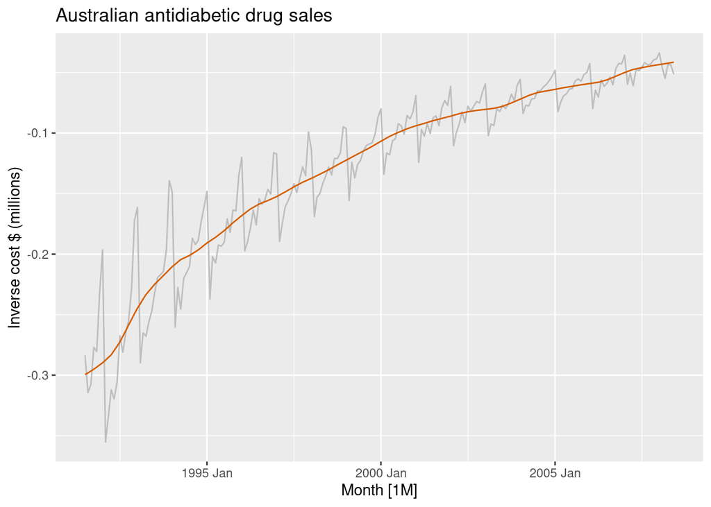

```r
components(dcmp) %>%
  as_tsibble() %>%
  autoplot(inv_cost, colour="gray") +
  geom_line(aes(y=trend), colour = "#D55E00") +
  labs(
    y = "Inverse cost $ (millions)",
    title = "Australian antidiabetic drug sales"
  )
```

## Further visual examples of additive vs. multiplicative

The following image clarifies the basic difference between the additive and multiplicative decomposition schemes. It has been borrowed from reference [2].

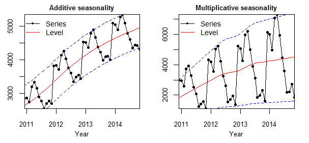

Figure 1: Multiplicative vs additive schemes. From reference [2].

In **reference [2]**, there is an **interesting interactive game where you can practice to recognize visual cues in additive and multiplicative schemes**. I strongly encourage you to spend some minutes doing this.

## Mathematical identification of additive vs multiplicative schemes

Visual inspection is a first approach to assessing the scheme type and it is interesting for developing your intuition as analysts. However, when you are faced with batched of time series you need to process, it is definately not the best approach. There are different ways in which the type of scheme could be evaluated.

One way of systematically assessing whether we should consider an additive or multiplicative scheme is to:

1. Decompose the series using a method that is appropriate for additive schemes and a method appropriate for a multiplicative scheme.
2. Assess the goodness of fit of each method. For example, assessing the amount of autocorrelation in the remainder of each decomposition.

Another possibility would be to:

1. Fit an exponential smoothing for an additive scheme
2. Fit an exponential smoothing for a multiplicative scheme.
3. Compare their Akaike Information Criteria (AIC) to see which fits best

When we are familiar with decomposition techniques at the end of the chapter, we can perform such an example.

## Mixed schemes

This is an alternative decomposition scheme. Here we have:

- Trend-cycle and seasonality components relating in a multiplicative manner.
- The remainder component superimposed in an additive scheme.

$$\boxed{y_t = (S_t \times T_t ) + R_t}$$

This scheme is relevant when:

- The irregular component of the oscillations $R_t$ does not grow with the level of the time series (and therefore is super-imposed in an additive manner)
- The seasonal component grows with the level of the time series, and therefore is combined with the trend in a multiplicative manner.

# Mathematical transformations

If the data shows variation that increases or decreases with the level of the series, a transformation can be useful. The notation we will use is:

- Original series: $y_1,\;...,y_t$.
- Transformed series: $w_1,\;...,w_t$.

## log() transformations

$$\boxed{w_t = log(y_t)}$$

**NOTE:** the **log** function returns the **natural logarithm**. Natural logarithms (base e) are actually the reference for the rest of the logarithms. There are multiple reasons for this, but essentially the number $e$ arises in many different situations (limits, infinite series, differential equations, complex variable) as a limit solution that makes it the “natural” reference for exponentials and logarithms.

As a reminder, **you should be able to always easily derive these equations**:

- $a^x = e^{xLn(a)}$
- $log_a(x) = \frac{log_b(x)}{log_b(a)}$

### Interpretation of logarithms

Changes in a log value are relative (or percentage changes) on the original scale. Example with log 10:

- An increase of 1 on the $log_{10}$ scale corresonds to multiplying by 10 on the original scale.

NOTE:

- $log(1+x)$ can be useful for data with zeros. Use the function `log1p()`

**Question** can anybody tell me why?

## Power transformations

$$\boxed{w_t = y_t^p}$$

They are not as interpretable as the logarithmic transformation. They also tend to stabilize seasonal variations, as we saw in the example of the adiabatic anti-drug sales.

## Box-Cox transformations

This transformation includes both logarithms and power transformations. They depend on the parameter $\lambda$.

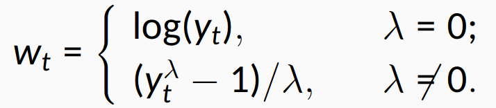

Figure 2: Box Cox transformation.

**Question:** what is the difference between a variable and a parameter?

Again, the transformation attempts to stabilize the seasonal fluctuations and random variations.

- The logarithm in a Box-Cox transformation is **always a natural logarithm**.
  - $\lambda = 1$: no substantial transformation
  - $\lambda = 0$: transformation equivalent to a natural logarithm.
  - $\lambda = 1/2$: Square root + linear transformation
  - $\lambda = 1/3$: Cubic root + linear transformation
  - $\lambda = -1$: Inverse transformation + 1
- Caveats when using this transformation
  - **If some data are zero or negative, use $\lambda > 0$**
  - Always check your results depicting the time series.
  - A low value of $\lambda$ can result in extremely large prediction intervals.
  - **If the best value of $\lambda$ is very close to 0, it is *preferable to use a log transformation* because it has *much better interpretability*.**

### Caveat of Box-Plot like transformations

Power transformations (such as the log-plot transformation) **require the variability of the series to vary proportionally to the level of the series**.

Let us look at data about the production of gas in Canada:

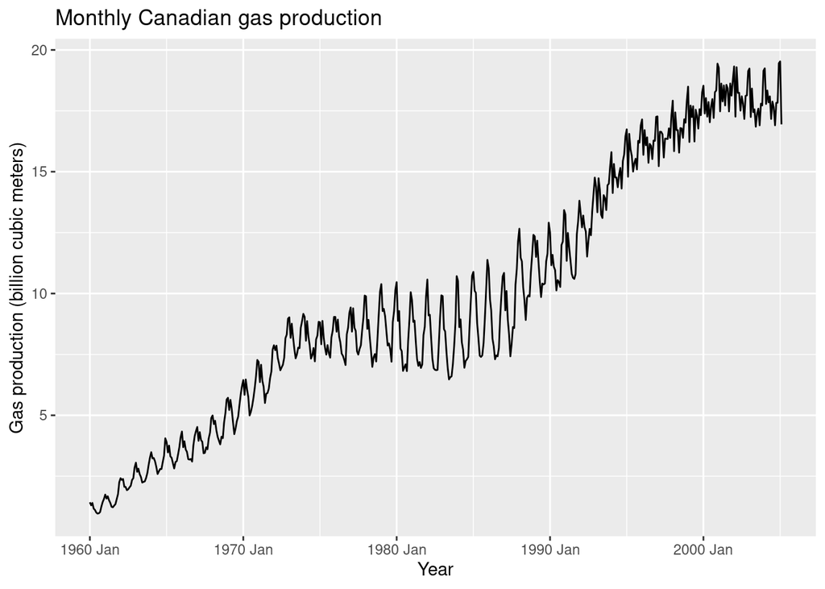

```r
canadian_gas %>%
  autoplot(Volume) +
  labs(
    x = "Year", y = "Gas production (billion cubic meters)",
    title = "Monthly Canadian gas production"
  )
```

- The **variation of the series is not proportional to the amount of gas produced in Canada.**
  - **For small and large production levels:** small variations in the seasonal pattern
  - **Moderate production leveks:** between 1975 and 1990. The variation in the seasonal pattern is large.

### Guerrero feautre to pick a variable for the parameter lambda

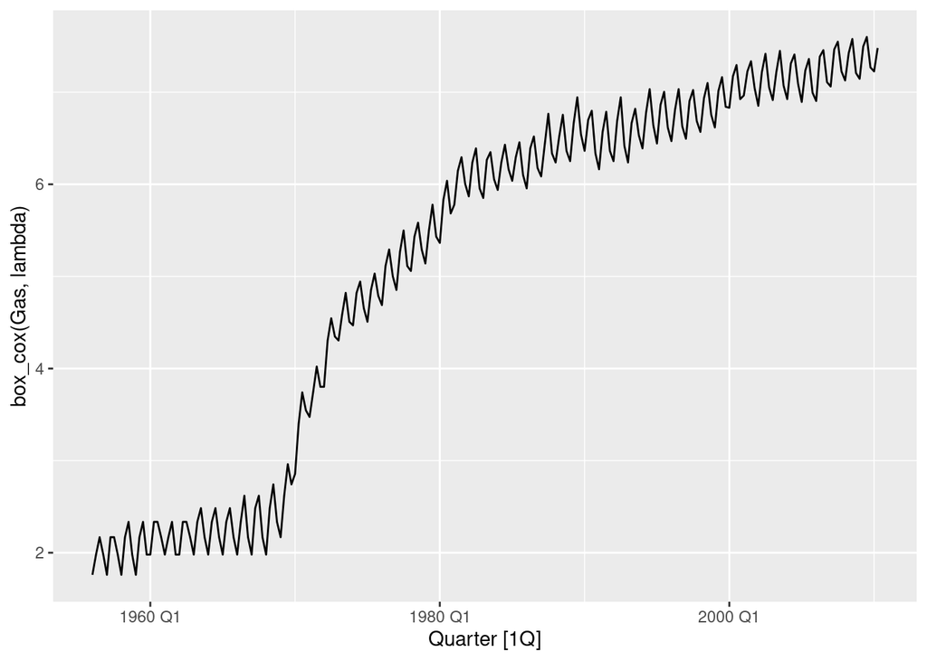

```r
lambda <- aus_production %>%
  features(Gas, features = guerrero) %>%
  pull(lambda_guerrero)

aus_production %>%
  autoplot(box_cox(Gas, lambda))
```

## Some notes on transformations

- **Often no transformation is needed** and we are able to produce a good forecast with the original data.
- Transformations that have good interpretability (such as log transformations) are preferred if they work well enough.
- Transformations **can have a very large effect on Prediction Intervals**.
- Transformations must be reversed to obtain forecasts on the original scale.

## EXERCISE

For each of the following series, make a graph of the data. If transforming seems appropriate, do so and describe the effect.

- United states GDP from `global economy`
- Slaughter of Victorian “Bulls, bullocks and steers” in `aus_livestock`
- Victorian Electricity Demand from `vic_elec`
- Tobacco from aus_production
- The following retail series:

```r
retail_series <- aus_retail %>%
  filter(`Series ID` == "A3349767W")
```

### United states gdp from global economy:

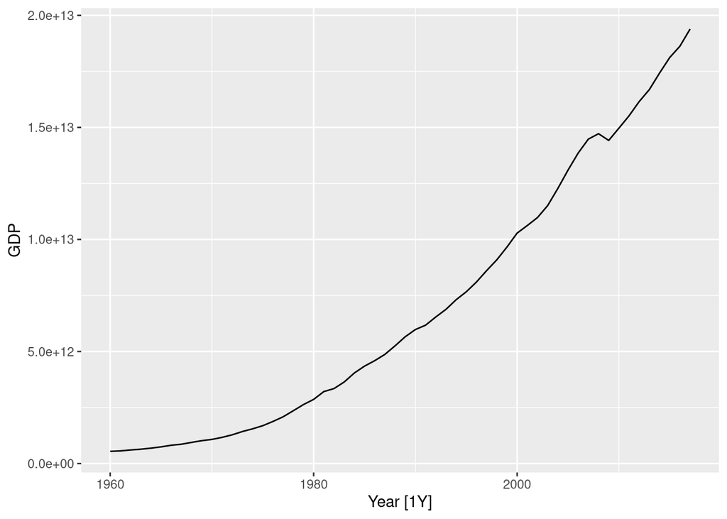

```r
us_economy <- global_economy %>%
  filter(Country == "United States")
us_economy %>%
  autoplot(GDP)
```

### Slaughter of Victorian “Bulls, bullocks and steers”

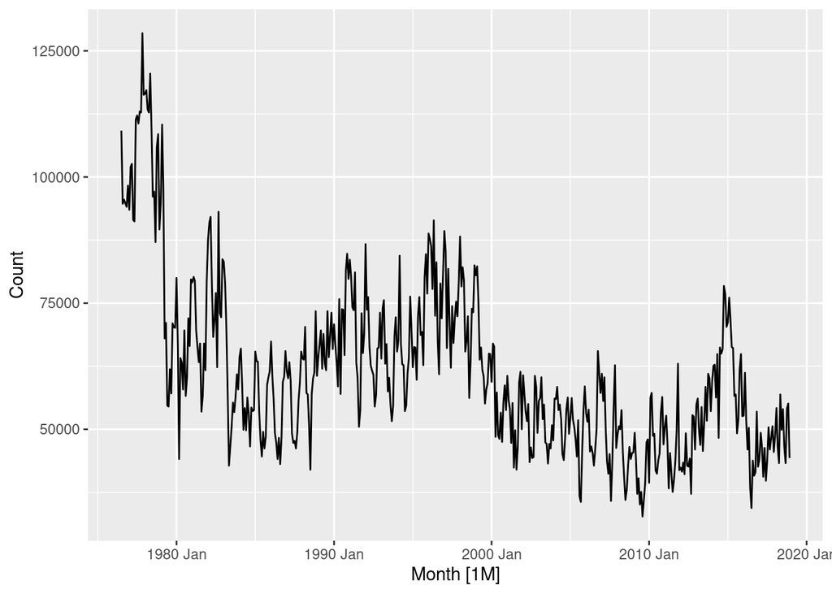

```r
vic_bulls <- aus_livestock %>%
  filter(State == "Victoria", Animal == "Bulls, bullocks and steers")
vic_bulls %>%
  autoplot(Count)
```

```r
# A log transformation ($\lambda = 0$) is pretty close and has much better interpretability.
```

[output not shown]

### Retail series

```
## Plot variable not specified, automatically selected `.vars = Turnover`
```

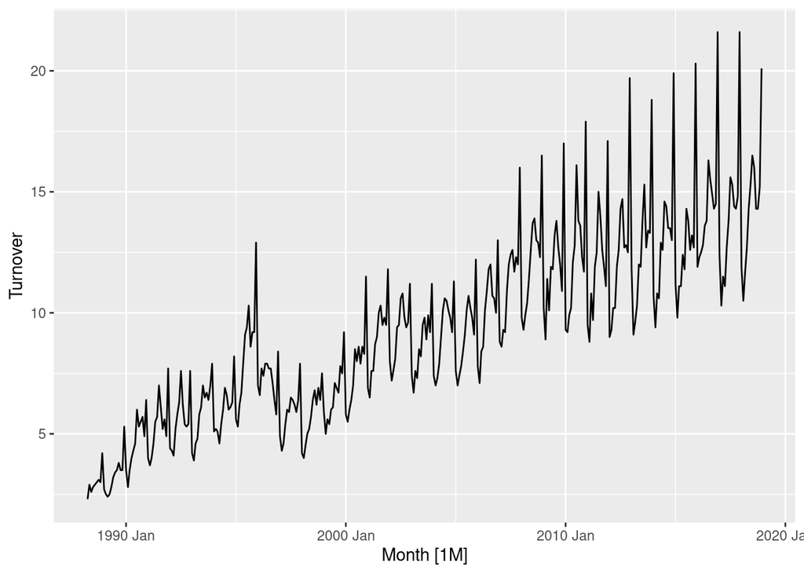

```r
retail_series <- aus_retail %>%
  filter(`Series ID` == "A3349767W")

autoplot(retail_series)
```